# team.Rmd

Chase Weida; Github: cweida; Bernard Fay: Github: bj99fay

3/11/2020

## Cleaning

```r
#defense
defense <- read_excel('cyclonesFootball2019.xlsx', sheet='Defensive')
defense <- data.frame(defense)
defense$Name <- as.factor(defense$Name)
defense$Opponent_Opponent <- as.factor(defense$Opponent_Opponent)

defense <- defense %>% mutate_at(.vars=c(3:11), .funs= list(as.numeric))
defClean <- defense
str(defClean)
```

```
## 'data.frame':    502 obs. of  11 variables:
##  $ Name             : Factor w/ 43 levels "Akers, Landen",..: 40 40 40 40 40 40 40 40 40 40 ...
##  $ Opponent_Opponent: Factor w/ 13 levels "Baylor","Iowa",..: 12 2 11 1 8 13 10 7 6 9 ...
##  $ Tackles_Solo     : num  4 4 3 4 3 1 7 3 6 5 ...
##  $ Tackles_ASST     : num  4 7 5 2 2 1 1 2 1 5 ...
##  $ Tackles_TFL      : num  0 0 0 0 1 0 0 0 1 1 ...
##  $ Tackles_Sack     : num  0 0 0 0 0 0 0 0 0 1 ...
##  $ Turnover_FF      : num  0 0 0 0 0 0 0 0 0 0 ...
##  $ Turnover_FR      : num  0 0 0 0 0 0 0 0 0 0 ...
##  $ Turnover_INT     : num  0 0 1 0 0 0 0 0 1 0 ...
##  $ Pass_QBH         : num  1 0 0 0 0 0 0 0 1 0 ...
##  $ Pass_PB          : num  1 2 0 0 0 1 0 0 0 0 ...
```

```r
#offense
offense <- read_excel('cyclonesFootball2019.xlsx', sheet='Offensive')
offense$Name <- as.factor(offense$Name)
offense$Opponent_Opponent <- as.factor(offense$Opponent_Opponent)
offense <-separate(offense, "Passing_CMP-ATT", into=c("Passing_CMP", "Passing_ATT"), sep="-\r\n ")
offense <- mutate_at(offense, .vars=c(3:13), .funs=list(as.numeric))

offClean <- offense
str(offClean)
```

```
## Classes 'tbl_df', 'tbl' and 'data.frame':    195 obs. of  13 variables:
##  $ Name             : Factor w/ 17 levels "Akers, Landen",..: 1 1 1 1 1 1 1 1 1 1 ...
##  $ Opponent_Opponent: Factor w/ 13 levels "Baylor","Iowa",..: 12 2 11 1 8 13 10 7 6 9 ...
##  $ Rushing_ATT      : num  0 0 1 0 0 0 0 0 0 0 ...
##  $ Rushing_YDS      : num  0 0 8 0 0 0 0 0 0 0 ...
##  $ Rushing_TD       : num  0 0 0 0 0 0 0 0 0 0 ...
##  $ Receiving_REC    : num  1 0 0 0 1 0 0 4 0 1 ...
##  $ Receiving_YDS    : num  21 0 0 0 32 0 0 39 0 7 ...
##  $ Receiving_TD     : num  0 0 0 0 0 0 0 0 0 0 ...
##  $ Passing_CMP      : num  NA NA NA NA NA NA NA NA NA NA ...
##  $ Passing_ATT      : num  NA NA NA NA NA NA NA NA NA NA ...
##  $ Passing_YDS      : num  NA NA NA NA NA NA NA NA NA NA ...
##  $ Passing_TD       : num  NA NA NA NA NA NA NA NA NA NA ...
##  $ Passing_INT      : num  NA NA NA NA NA NA NA NA NA NA ...
```

```r
#biography
biography <- read_excel('cyclonesFootball2019.xlsx', sheet='Biography')
biography <- data.frame(biography)

biography <- biography %>% separate(Height, sep = "-", into = c('Ft', 'inch'), remove = TRUE)
biography$Ft <- as.numeric(biography$Ft)
biography$inch <- as.numeric(biography$inch)

biography$Height <- biography %>% transmute(inches = (Ft * 12) + inch)
biography <- biography %>% select(-c(3,4))
biography <- biography %>% mutate_at(.vars = c(1,2,4,5,6), .funs = list(as.factor)) %>% mutate_at(.vars = c(3), .funs = list(as.numeric))
bioClean <- biography
str(bioClean)
```

```
## 'data.frame':    105 obs. of  7 variables:
##  $ Name      : Factor w/ 105 levels "Akers, Landen",..: 1 2 3 4 5 6 7 8 9 10 ...
##  $ Position  : Factor w/ 14 levels "Deep Snapper",..: 14 13 14 9 2 3 3 4 4 11 ...
##  $ Weight    : num  188 245 204 195 190 235 255 285 300 215 ...
##  $ Class     : Factor w/ 8 levels "Freshman","Junior",..: 5 5 3 5 5 4 5 5 2 1 ...
##  $ Hometown  : Factor w/ 86 levels "Akron, Ohio",..: 16 54 73 50 36 20 41 41 86 14 ...
##  $ Highschool: Factor w/ 96 levels "Ames","Armwood",..: 88 59 2 15 49 16 72 72 95 10 ...
##  $ Height    :'data.frame':  105 obs. of  1 variable:
##   ..$ inches: num  72 79 77 72 72 75 74 74 72 78 ...
```

## Tidying(1)

### 1.

```r
dat1 <- defClean %>% pivot_longer(cols=c(3:11), names_to="Statistic")
```

### 2.

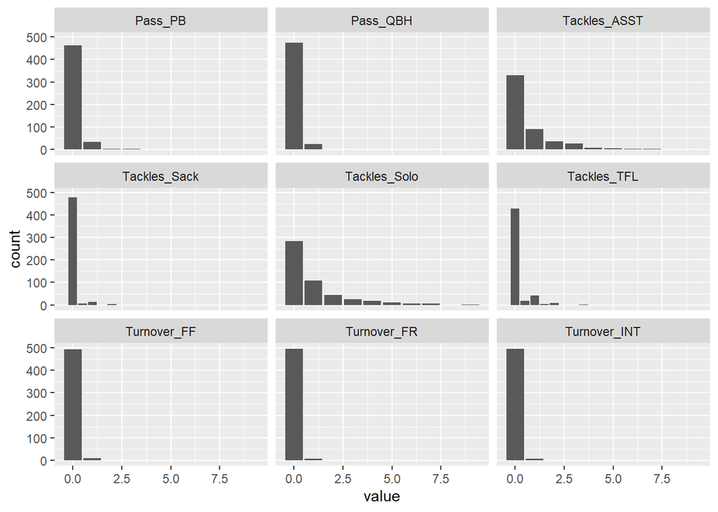

```r
dat1 %>% ggplot(aes(x=as.numeric(value))) + geom_bar(stat="count") + facet_wrap(~Statistic) + xlab("value")
```

There are several defensive skills that are rare. Pass_PB, Pass_QBH, Tackles_Sack, Tackles_TFL, Turnover_FF, Turnover_FR, and Turnover_INT are the rare defensive skills because very few players have non-zero values in these areas.

### 3.

```r
dat1 %>% head()
```

```
## # A tibble: 6 x 4
##   Name            Opponent_Opponent Statistic    value
##   <fct>           <fct>             <chr>        <dbl>
## 1 White, Lawrence UNI               Tackles_Solo     4
## 2 White, Lawrence UNI               Tackles_ASST     4
## 3 White, Lawrence UNI               Tackles_TFL      0
## 4 White, Lawrence UNI               Tackles_Sack     0
## 5 White, Lawrence UNI               Turnover_FF      0
## 6 White, Lawrence UNI               Turnover_FR      0
```

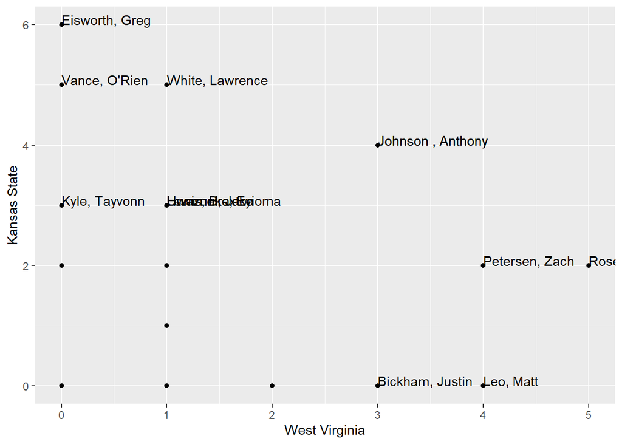

```r
dat2 <- dat1 %>%
        filter(Opponent_Opponent %in% c("Kansas State", "West Virginia") & Statistic == "Tackles_Solo") %>%
        select(Name, Opponent_Opponent, value) %>%
        pivot_wider(names_from = Opponent_Opponent, values_from = value)
dat2$`West Virginia`[is.na(dat2$`West Virginia`)] <- 0
dat2$`Kansas State`[is.na(dat2$`Kansas State`)] <- 0
dat2 %>% ggplot(aes(x=`West Virginia`, y=`Kansas State`)) + geom_point() +
        geom_text(aes(label=ifelse(`West Virginia`>2, as.character(Name),'')), hjust=0, vjust=0) +
        geom_text(aes(label=ifelse(`Kansas State`>2, as.character(Name),'')), hjust=0, vjust=0)
```

Iowa State had better defense against Kansas State as there were several players with more than 2 tackles in that game, compared to only five players with >2 tackles in the West Virginia game.